# Estudo de Caso 01: Comparação do IMC médio de alunos do PPGEE-UFMG ao longo de dois semestres

Joao Paulo Lara Pinto, Thales Henrique de Oliveira Gonçalves, Henrique Alves Barbosa, Matheus Cascalho dos Santos

05 de Novembro de 2024

## Descrição do Problema

O IMC é uma medida utilizada na área de saúde como um indicador simples capaz de encontrar correlações entre o peso e altura do paciente com doenças decorrentes de obesidade, sendo inclusive capaz de classificar em diferentes grupos para obter maior precisão na análise em questão [1], [2].

Apesar dos problemas decorrentes da simplicidade do teste [3], [4] e métodos mais robustos tais como a bioimpedância [5] estarem presentes, continua sendo uma medida interessante pela facilidade e baixo custo de encontrá-la. A partir de tal importância médica, muitas questões naturalmente surgem relacionadas a testes entre diferentes populações.

Neste estudo, serão propostos três testes de forma a compreender possíveis relações e diferenças presentes na amostragem realizada nos anos de 2016 e 2017 no Departamento de Engenharia da UFMG. Os testes propostos são:

- Diferença entre IMC de Homens e Mulheres;
- Diferença de IMC entre os dois anos em estudo;
- Diferença entre alunos de Graduação e Pós-Graduação em 2016.

Por meio destes testes, podemos obter informações relevantes capazes de compreender diferenças baseadas em idade, sexo e ano de estudo.

## Design dos Experimentos

Nos experimentos aqui realizados, procuramos extrair o máximo de informações possíveis de dados que já foram extraídos. A partir disto, problemas estatísticos naturalmente irão surgir, sendo alguns deles:

- Diferentes tamanhos de amostra;
- Poucos dados;
- Amostra não representativa de todo o departamento.

Apesar de tais problemas existirem, será aproveitada ao máximo a robustez existente nos experimentos.

### Diferença entre IMC de Homens e Mulheres

Dada a conhecida diferença na composição corporal entre homens e mulheres [6], torna-se relevante analisar os índices de IMC dentro do universo em estudo. Em termos gerais, observam-se valores semelhantes de IMC entre os sexos [7], apesar das variações na composição corporal. Para aprofundar essa análise, podemos testar a hipótese alternativa de que o IMC médio masculino ($\mu_{imcm}$) seja superior ao feminino ($\mu_{imcf}$).
$$\begin{cases} H_0: \mu_{imcf} =
\mu_{imcm}&\\H_1: \mu_{imcf}<\mu_{imcm}\end{cases}$$

Estudos referentes à normalidade de ambas distribuições foram realizados, assim como um teste de comparação das variâncias de Fligner-Killen.

O valor de ($\delta^*$) utilizado neste teste foi selecionado com base na relevância das faixas pré-definidas de IMC, sendo que para que pessoa no meio de uma faixa precisa ter uma alteração de 2.5 em seu IMC para alternar de faixa, sendo ($\delta^*=2.5$).

O valor de $\alpha=0.05$ buscou manter o padrão encontrado na literatura médica, assim como esperava-se encontrar um valor de $\beta=0.8$ para corroborar com não encontrarmos falsos negativos.

### Diferença de IMC entre os dois anos em estudo;

Para cada um dos testes, iremos avaliar se ($\mu_{2016}$) é igual a ($\mu_{2017}$).

### Diferença entre alunos de Graduação e Pós-Graduação em 2016;

Realizamos para este experimento um teste entre a diferença da média do IMC entre alunos de graduação ($\mu_{grad}$) e pós graduação ($\mu_{pos}$) de forma a testar se a idade é um fator que influencia a saúde dos alunos do departamento. Um estudo análogo, realizado na University of South Alabama, apresentou um IMC médio levemente superior de alunos da pós-graduação em enfermagem, em relação aos alunos da graduação do mesmo curso [8].

## Experimentos

### Diferença entre IMC de Homens e Mulheres

O primeiro passo é carregar os dados e calcular o IMC das amostras.

```r
imc2016 <- read.csv('imc_20162.csv')
imc2017 <- read.csv('CS01_20172.csv', sep = ';')

# Filtragem de dados
imc2016 <- imc2016[imc2016$Course == 'PPGEE',]

# Padronização do dataframe
colnames(imc2016)[colnames(imc2016)=='Gender'] <- 'Sex'
colnames(imc2016)[colnames(imc2016)=='Height.m'] <- 'height.m'
colnames(imc2016)[colnames(imc2016)=='Weight.kg'] <- 'weight.kg'
colnames(imc2017)[colnames(imc2017)=='Weight.kg'] <- 'weight.kg'
imc2016 = imc2016[,c('Sex', 'height.m', 'weight.kg')]
imc2017 = imc2017[,c('Sex', 'height.m', 'weight.kg')]
imc2016$amostra <- '2016'
imc2017$amostra <- '2017'

# Calculando o IMC de cada população
imc2016$imc <- imc2016$weight.kg/(imc2016$height.m^2)
imc2017$imc <- imc2017$weight.kg/(imc2017$height.m^2)

# União dos dataframes
imc <- rbind(imc2016, imc2017)

# Segregação de dados entre Homens e Mulheres
imc_feminino <- imc[imc$Sex == 'F',]
imc_masculino <- imc[imc$Sex == 'M',]
```

Em seguida, executamos o teste de Fligner-Killeen para verificar se a premissa de que as variâncias são iguais se aplica no experimento.

```r
fligner.test(imc ~ Sex, data = imc)
```

```
##
##  Fligner-Killeen test of homogeneity of variances
##
## data:  imc by Sex
## Fligner-Killeen:med chi-squared = 1.0504, df = 1, p-value = 0.3054
```

O p-valor resultante, de 0,3054, indica que não há evidências o suficiente para rejeitar a hipótese nula, ou seja, corrobora com a hipótese de que as variâncias dos dois grupos são iguais. Executamos, então, o teste de Shapiro-Wilker para verificar a premissa de normalidade das amostras.

```r
shapiro.test(imc$imc[imc$Sex == "F"])
```

```
##
##  Shapiro-Wilk normality test
##
## data:  imc$imc[imc$Sex == "F"]
## W = 0.91991, p-value = 0.3179
```

```r
shapiro.test(imc$imc[imc$Sex == "M"])
```

```
##
##  Shapiro-Wilk normality test
##
## data:  imc$imc[imc$Sex == "M"]
## W = 0.94947, p-value = 0.0618
```

Novamente, não há evidências para rejeitar $H_0$. Com as premissas validadas, executamos o t-test:

```r
t.test(imc$imc ~ imc$Sex,
       alternative = "less",
       mu          = 0,
       var.equal   = TRUE,
       conf.level  = 0.95)
```

```
##
##  Two Sample t-test
##
## data:  imc$imc by imc$Sex
## t = -3.6409, df = 51, p-value = 0.0003175
## alternative hypothesis: true difference in means between group F and group M is less than 0
## 95 percent confidence interval:
##       -Inf -2.421576
## sample estimates:
## mean in group F mean in group M
##        20.12522        24.61073
```

O resultado do p-valor igual a 0.0003175 indica que há evidência suficiente para rejeitar $H_0$, ou seja, rejeitamos a hipótese de que homens e mulheres possuem o mesmo imc. Finalmente, identificamos o poder do teste

```r
power.t.test(delta       = 2.5, # mínimo que faz a mudança de faixa de IMC
             sd          = sd(imc$imc),
             sig.level   = 0.05,
             n = length(imc$imc),
             type        = "two.sample",
             alternative = "one.sided")
```

```
##
##      Two-sample t test power calculation
##
##               n = 53
##           delta = 2.5
##              sd = 4.043382
##       sig.level = 0.05
##           power = 0.935392
##     alternative = one.sided
##
## NOTE: n is number in *each* group
```

Esse resultado mostra que temos 93.5% de confiança de que não estamos cometendo um falso negativo em nossa conclusão.

### Diferença de IMC entre os dois anos em estudo;

Para esse o próximo experimos utilizaremos os dados carregados na seção anterior. Validamos as premissas de normalidade e variâncias da seguinte forma:

```r
fligner.test(imc ~ amostra, data = imc_feminino)
```

```
##
##  Fligner-Killeen test of homogeneity of variances
##
## data:  imc by amostra
## Fligner-Killeen:med chi-squared = 0.71101, df = 1, p-value = 0.3991
```

```r
shapiro.test(imc_feminino$imc[imc_feminino$amostra == "2017"])
```

```
##
##  Shapiro-Wilk normality test
##
## data:  imc_feminino$imc[imc_feminino$amostra == "2017"]
## W = 0.7475, p-value = 0.03659
```

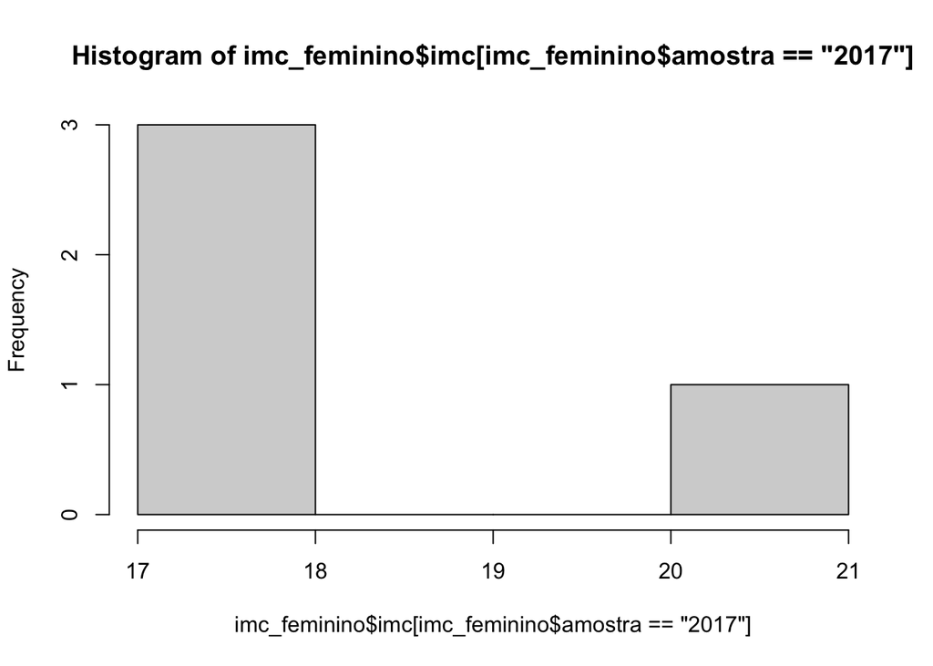

```r
hist(imc_feminino$imc[imc_feminino$amostra == "2017"])
```

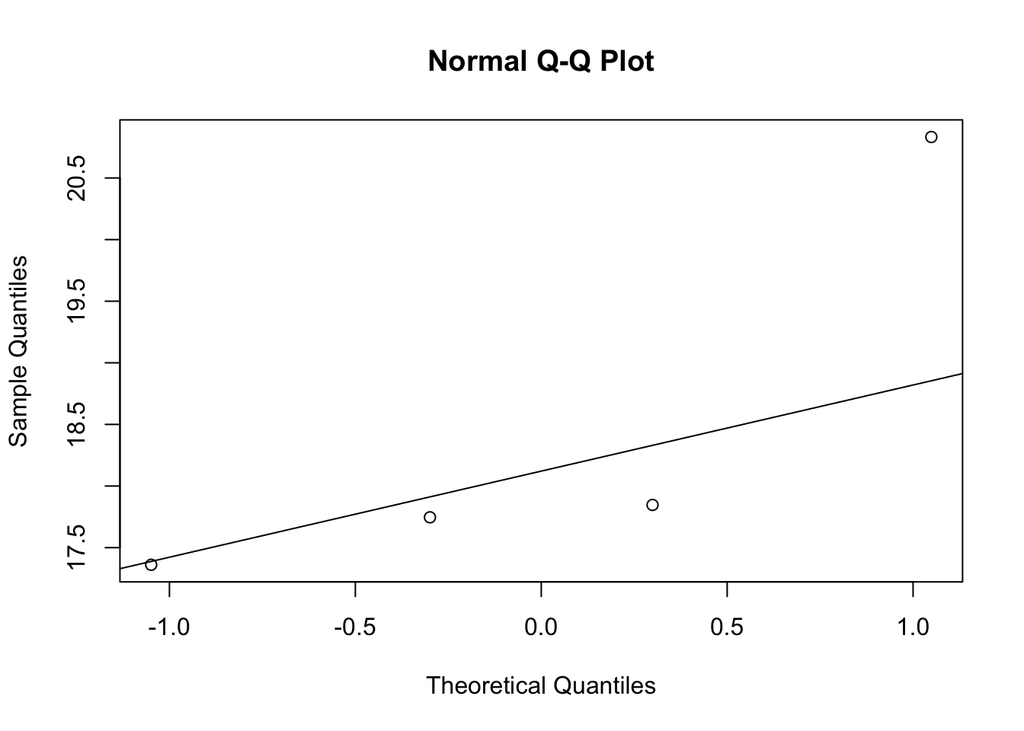

```r
qqnorm(imc_feminino$imc[imc_feminino$amostra == "2017"])
qqline(imc_feminino$imc[imc_feminino$amostra == "2017"])
```

```r
shapiro.test(imc_feminino$imc[imc_feminino$amostra == "2016"])
```

```
##
##  Shapiro-Wilk normality test
##
## data:  imc_feminino$imc[imc_feminino$amostra == "2016"]
## W = 0.91974, p-value = 0.4674
```

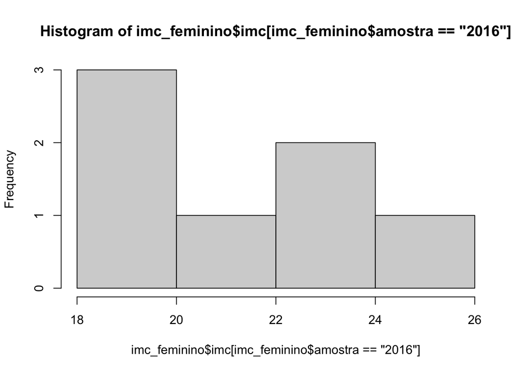

```r
hist(imc_feminino$imc[imc_feminino$amostra == "2016"])
```

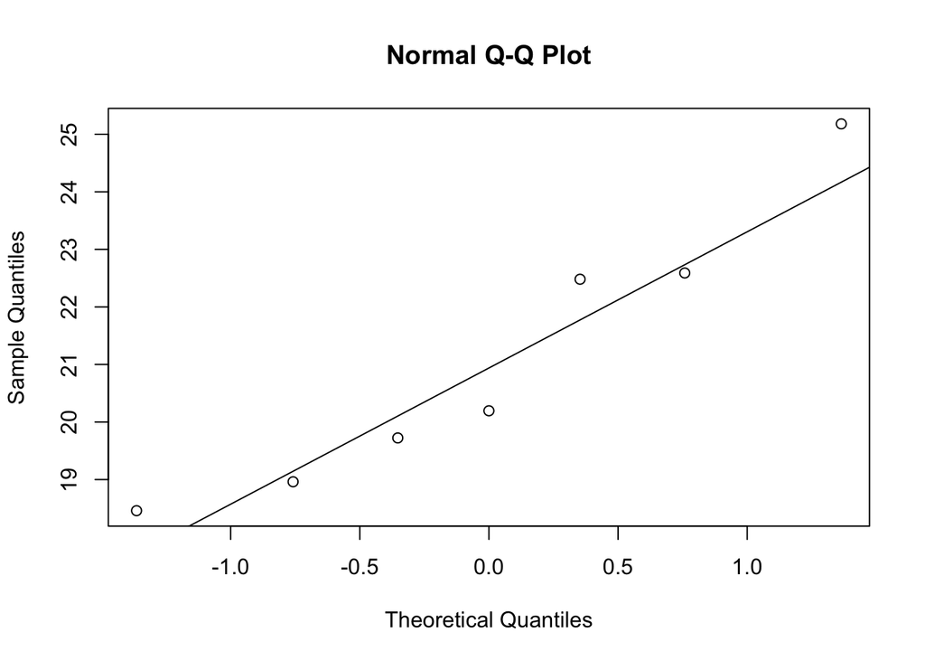

```r
qqnorm(imc_feminino$imc[imc_feminino$amostra == "2016"])
qqline(imc_feminino$imc[imc_feminino$amostra == "2016"])
```

Observamos que na amostra de imc_feminino o p-valor foi menor que 0.05 para o teste de Shapiro-Wilker, o que indicaria que a amostra não segue uma distribuição normal. Entretanto, como observamos no Q-Q Plot, esse desvio da normalidade se dá na cauda direita da amostra. Como o teste t é um teste robusto a desvios de normalidade nos extremos da distribuição, aceitamos que esse desvio de normalidade não irá prejudicar o resultado da análise. Nota-se também que a amostra feminina é muito menor que a amostra masculina. Uma melhoria que propomos ao teste e o aumento na coleta de dados de imc feminino, para trazer maior segurança nos resultados do teste.

Experimento:

```r
t.test(imc_feminino$imc ~ imc_feminino$amostra,
       alternative = "less",
       mu          = 0,
       var.equal   = TRUE,
       conf.level  = 0.95)
```

```
##
##  Two Sample t-test
##
## data:  imc_feminino$imc by imc_feminino$amostra
## t = 1.9308, df = 9, p-value = 0.9572
## alternative hypothesis: true difference in means between group 2016 and group 2017 is less than 0
## 95 percent confidence interval:
##     -Inf 5.14222
## sample estimates:
## mean in group 2016 mean in group 2017
##           21.08443           18.44660
```

O p-valor de 0.9572 indica que não há evidência suficiente para rejeitar $H_0$, ou seja, não há evidência para rejeitar a hipótese de que o IMC dos dois anos seja igual.

### Diferença entre alunos de Graduação e Pós-Graduação em 2016;

Assim como nos experimentos anteriores, realizamos os testes de normalidade e de variância igual para as amostras de alunos da graduação e da pós-graduação.

```r
imc2016 <- read.csv('imc_20162.csv')
imc2016$imc <- imc2016$Weight.kg/(imc2016$Height.m^2)

fligner.test(imc ~ Course, data = imc2016) # H0: VARIANCIAS IGUAIS
```

```
##
##  Fligner-Killeen test of homogeneity of variances
##
## data:  imc by Course
## Fligner-Killeen:med chi-squared = 0.025593, df = 1, p-value = 0.8729
```

```r
shapiro.test(imc2016$imc[imc2016$Course == "PPGEE"])
```

```
##
##  Shapiro-Wilk normality test
##
## data:  imc2016$imc[imc2016$Course == "PPGEE"]
## W = 0.92185, p-value = 0.03854
```

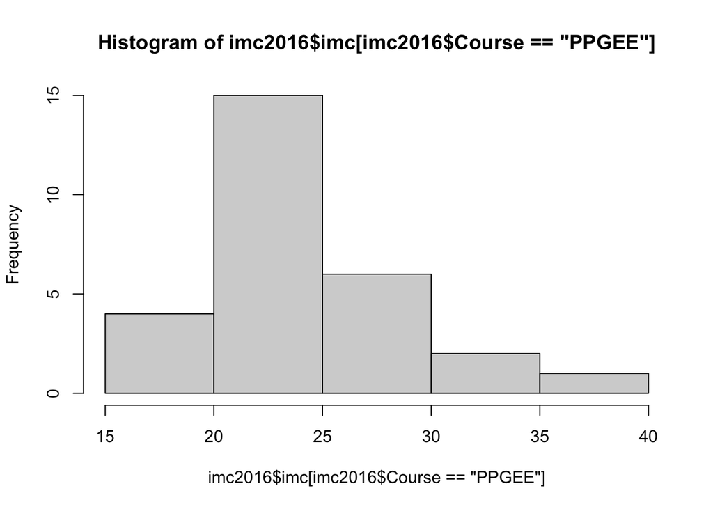

```r
hist(imc2016$imc[imc2016$Course == "PPGEE"])
```

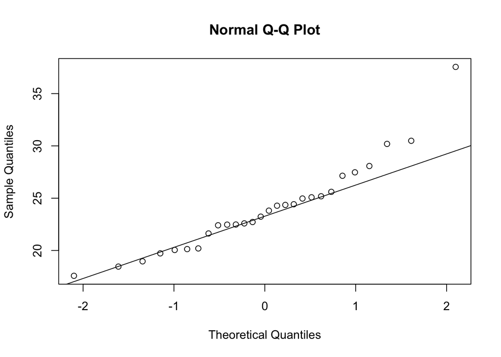

```r
qqnorm(imc2016$imc[imc2016$Course == "PPGEE"])
qqline(imc2016$imc[imc2016$Course == "PPGEE"])
```

Assim como no experimento anterior para a amostra de imc feminino, a amostra de imc dos alunos do PPGEE não segue uma distribuição normal na cauda direita. Entretanto, para os fins desse estudo, dada a robustez do t-test à desvios de normalidade nos extremos da distribuição, podemos manter a premissa de normalidade e aplicar o t-teste.

```r
shapiro.test(imc2016$imc[imc2016$Course == "ENGSIS"])
```

```
##
##  Shapiro-Wilk normality test
##
## data:  imc2016$imc[imc2016$Course == "ENGSIS"]
## W = 0.90993, p-value = 0.05474
```

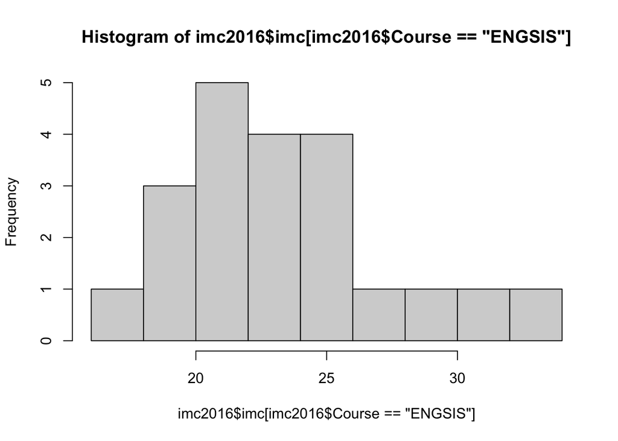

```r
hist(imc2016$imc[imc2016$Course == "ENGSIS"])
```

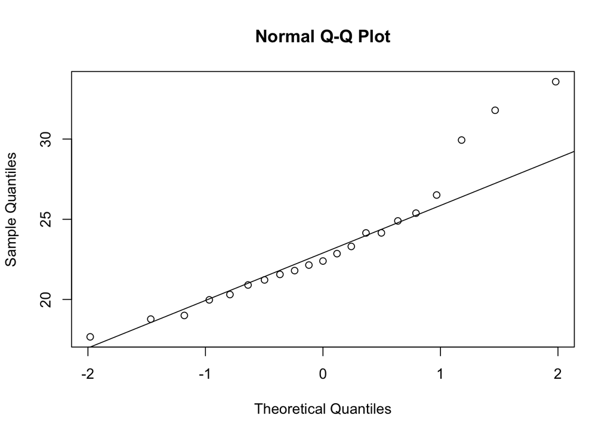

```r
qqnorm(imc2016$imc[imc2016$Course == "ENGSIS"])
qqline(imc2016$imc[imc2016$Course == "ENGSIS"])
```

```r
t.test(imc2016$imc ~ imc2016$Course,
       alternative = "less",
       mu          = 0,
       var.equal   = TRUE,
       conf.level  = 0.95)
```

```
##
##  Two Sample t-test
##
## data:  imc2016$imc by imc2016$Course
## t = -0.43504, df = 47, p-value = 0.3328
## alternative hypothesis: true difference in means between group ENGSIS and group PPGEE is less than 0
## 95 percent confidence interval:
##      -Inf 1.512432
## sample estimates:
## mean in group ENGSIS  mean in group PPGEE
##             23.44369             23.97307
```

O p-valor de 0.3328 indica que não há evidência suficiente para rejeitar $H_0$, ou seja, não há evidência para rejeitar a hipótese de que o IMC dos alunos dos dois cursos seja igual.

## Discussões e Conclusões

Em todos os testes, o fato de trabalharmos com dados históricos apresentou-se como uma complexidade que nos obrigou a ter uma cautela adicional. O fato de possuirmos diferentes tamanhos de amostras em todos os testes fez com que procuremos explorar o máximo o poder dos testes utilizando por exemplo testes em que podíamos considerar variâncias iguais.

O intuito de extrapolar os resultados de uma amostra centrada em uma única disciplina para todo o departamento de Engenharia Elétrica rompe com as premissas básicas de uma amostra iid, sendo que nos apoiamos na suposição de que como qualquer aluno pode se matricular na disciplina os alunos matriculados representariam todo o curso. Essa suposição, apesar de ser razoável considerando que a altura e peso são fatores comumente individuais, poderia não ser fidedigna com os testes, sendo que possíveis estudos de correlação entre indivíduos poderia ser realizada para fortalecer mais as conclusões estabelecidas.

### Diferença entre IMC de Homens e Mulheres

Corroborando a rejeição da hipótese nula, pode-se assumir que o IMC feminino de fato é menor que o IMC masculino. Tais resultados podem advir de diferenças na composição muscular e de gordura, assim como a própria fisionomia. Maiores estudos podem ser realizados para validar tais hipóteses desde que novos dados sejam extraidos.

### Diferença entre alunos de Graduação e Pós-Graduação em 2016

Na realização deste experimento, é interessante notar que o teste de normalidade não possuiu nível de significância estatística esperada, apesar disto devido ao teste t ser robusto à variações de normalidade o experimento pode ser executado. Novamente não podemos afirmar de forma fidedigna que as duas amostras possuem diferença no valor das médias do IMC, sendo que experimentos com um maior número de dados e maior aleatoriedade poderiam fornecer maior significado estatístico.

# Bibliografia

[1]

Centers for Disease Control and Prevention, “About body mass index (BMI).” 2024. Available: https://www.cdc.gov/bmi/about/index.html

[2]

C. B. Weir and A. Jan, “BMI classification percentile and cut off points,” 2019.

[3]

F. Q. Nuttall, “Body mass index: Obesity, BMI, and health: A critical review,” *Nutrition today*, vol. 50, no. 3, pp. 117–128, 2015.

[4]

N. R. Shah and E. R. Braverman, “Measuring adiposity in patients: The utility of body mass index (BMI), percent body fat, and leptin,” *PloS one*, vol. 7, no. 4, p. e33308, 2012.

[5]

M. G. Branco *et al.*, “Bioelectrical impedance analysis (BIA) for the assessment of body composition in oncology: A scoping review,” *Nutrients*, vol. 15, no. 22, p. 4792, 2023.

[6]

M. A. Bredella, “Sex differences in body composition,” *Sex and gender factors affecting metabolic homeostasis, diabetes and obesity*, pp. 9–27, 2017.

[7]

M. D. Olfert *et al.*, “Self-reported vs. Measured height, weight, and BMI in young adults,” *International journal of environmental research and public health*, vol. 15, no. 10, p. 2216, 2018.

[8]

R. J. Graves *et al.*, “Undergraduate versus graduate nursing students: Differences in nutrition, physical activity, and self-reported body mass index,” *Journal of American College Health*, vol. 70, no. 7, pp. 1941–1946, 2022.